## Importing modules

```python
import pandas as pd
import requests
import os
import json
import re as re
from matplotlib import pyplot as plt
```

# Wrangle data

```python
# Creating forlder
folder_name = 'tweeter_project_data'
if not os.path.exists(folder_name):
    os.makedirs(folder_name)
```

```python
# Wrangling image-predictions
url = 'https://d17h27t6h515a5.cloudfront.net/topher/2017/August/599fd2ad_image-predictions/image-predictions.tsv'
response = requests.get(url)
with open(os.path.join(folder_name,url.split('/')[-1]),mode='wb') as file:
    file.write(response.content)
os.listdir(folder_name)
```

```
['image-predictions.tsv', 'tweet_json.txt', 'twitter-archive-enhanced.csv']
```

```python
# Wrangling image_predictions.tsv
df_images_predictions = pd.read_csv('./tweeter_project_data/image-predictions.tsv', sep='\t')
df_images_predictions.sample(5)
```

|  | tweet_id | jpg_url | img_num | p1 | p1_conf | p1_dog | p2 | p2_conf | p2_dog | p3 | p3_conf | p3_dog |
| --- | --- | --- | --- | --- | --- | --- | --- | --- | --- | --- | --- | --- |
| 1654 | 810254108431155201 | https://pbs.twimg.com/media/Cz6Z0DgWIAAfdvp.jpg | 1 | Staffordshire_bullterrier | 0.292556 | True | American_Staffordshire_terrier | 0.261233 | True | Border_terrier | 0.062375 | True |
| 502 | 675870721063669760 | https://pbs.twimg.com/media/CWEs1b-WEAEhq82.jpg | 1 | golden_retriever | 0.263892 | True | Welsh_springer_spaniel | 0.184193 | True | beagle | 0.182241 | True |
| 1290 | 751456908746354688 | https://pbs.twimg.com/ext_tw_video_thumb/75145... | 1 | golden_retriever | 0.714409 | True | Afghan_hound | 0.066163 | True | chow | 0.028413 | True |
| 1196 | 740373189193256964 | https://pbs.twimg.com/media/CkZVdJ6WYAAXZ5A.jpg | 3 | golden_retriever | 0.807644 | True | kuvasz | 0.101286 | True | Labrador_retriever | 0.023785 | True |
| 871 | 697943111201378304 | https://pbs.twimg.com/media/Ca-XjfiUsAAUa8f.jpg | 1 | Great_Dane | 0.126924 | True | Greater_Swiss_Mountain_dog | 0.110037 | True | German_short-haired_pointer | 0.090816 | True |

```python
# Wrangling tweet_json.txt
with open('./tweeter_project_data/tweet_json.txt') as file:
    df_tweet_json = pd.DataFrame((json.loads(line) for line in file), columns = ['id', 'id_str', 'favorite_count', 'retweet_count', 'source', 'lang', 'created_at', 'coordinates'])
df_tweet_json.columns = ['Tweet_id', 'Tweet_id_str', 'Favorites', 'Retweets', 'Tweet_source', 'Language', 'Tweet_date', 'Coordinates']
#df_api.set_index('tweet_id', inplace = True)
df_tweet_json.sample(5)
```

|  | Tweet_id | Tweet_id_str | Favorites | Retweets | Tweet_source | Language | Tweet_date | Coordinates |
| --- | --- | --- | --- | --- | --- | --- | --- | --- |
| 1554 | 688828561667567616 | 688828561667567616 | 1508 | 420 | <a href="http://twitter.com/download/iphone" r... | en | Sun Jan 17 21:01:41 +0000 2016 | None |
| 825 | 769212283578875904 | 769212283578875904 | 5980 | 1969 | <a href="http://twitter.com/download/iphone" r... | en | Fri Aug 26 16:37:54 +0000 2016 | None |
| 172 | 858471635011153920 | 858471635011153920 | 22640 | 5271 | <a href="http://twitter.com/download/iphone" r... | en | Sun Apr 30 00:02:42 +0000 2017 | None |
| 2318 | 666437273139982337 | 666437273139982337 | 131 | 52 | <a href="http://twitter.com/download/iphone" r... | en | Tue Nov 17 02:06:42 +0000 2015 | None |
| 1451 | 695629776980148225 | 695629776980148225 | 5020 | 2377 | <a href="http://twitter.com/download/iphone" r... | en | Fri Feb 05 15:27:17 +0000 2016 | None |

```python
# Wrangling twitter-archive-enhanced.csv
df_tweet_archive = pd.read_csv('./tweeter_project_data/twitter-archive-enhanced.csv')
df_tweet_archive.sample(5)
```

|  | tweet_id | in_reply_to_status_id | in_reply_to_user_id | timestamp | source | text | retweeted_status_id | retweeted_status_user_id | retweeted_status_timestamp | expanded_urls | rating_numerator | rating_denominator | name | doggo | floofer | pupper | puppo |
| --- | --- | --- | --- | --- | --- | --- | --- | --- | --- | --- | --- | --- | --- | --- | --- | --- | --- |
| 1704 | 680889648562991104 | NaN | NaN | 2015-12-26 23:15:17 +0000 | <a href="http://twitter.com/download/iphone" r... | This is Cheesy. It's her birthday. She's patie... | NaN | NaN | NaN | https://twitter.com/dog_rates/status/680889648... | 9 | 10 | Cheesy | None | None | None | None |
| 1617 | 685169283572338688 | NaN | NaN | 2016-01-07 18:41:01 +0000 | <a href="http://twitter.com/download/iphone" r... | Meet Gerbald. He just found out he's adopted. ... | NaN | NaN | NaN | https://twitter.com/dog_rates/status/685169283... | 11 | 10 | Gerbald | None | None | pupper | None |
| 493 | 813202720496779264 | NaN | NaN | 2016-12-26 02:00:11 +0000 | <a href="http://twitter.com/download/iphone" r... | Here's a doggo who has concluded that Christma... | NaN | NaN | NaN | https://twitter.com/dog_rates/status/813202720... | 11 | 10 | None | doggo | None | None | None |
| 1413 | 698907974262222848 | NaN | NaN | 2016-02-14 16:33:40 +0000 | <a href="http://twitter.com/download/iphone" r... | This dog is never sure if he's doing the right... | NaN | NaN | NaN | https://twitter.com/dog_rates/status/698907974... | 10 | 10 | None | None | None | None | None |
| 1903 | 674638615994089473 | NaN | NaN | 2015-12-09 17:15:54 +0000 | <a href="http://twitter.com/download/iphone" r... | This pupper is fed up with being tickled. 12/1... | NaN | NaN | NaN | https://twitter.com/dog_rates/status/674638615... | 12 | 10 | None | None | None | pupper | None |

# Accessing Data

## Image-predictions

### Let's find the problems about this dataset

```python
df_images_predictions.sample(5)
```

|  | tweet_id | jpg_url | img_num | p1 | p1_conf | p1_dog | p2 | p2_conf | p2_dog | p3 | p3_conf | p3_dog |
| --- | --- | --- | --- | --- | --- | --- | --- | --- | --- | --- | --- | --- |
| 110 | 667886921285246976 | https://pbs.twimg.com/media/CUTPnPCW4AI7R0y.jpg | 1 | Pomeranian | 0.800432 | True | Pekinese | 0.168445 | True | Chihuahua | 0.008950 | True |
| 631 | 680940246314430465 | https://pbs.twimg.com/media/CXMvio7WQAAPZJj.jpg | 1 | soft-coated_wheaten_terrier | 0.289598 | True | West_Highland_white_terrier | 0.157195 | True | toy_poodle | 0.074435 | True |
| 2009 | 878281511006478336 | https://pbs.twimg.com/media/DDBIX9QVYAAohGa.jpg | 1 | basset | 0.320420 | True | collie | 0.215975 | True | Appenzeller | 0.128507 | True |
| 837 | 694329668942569472 | https://pbs.twimg.com/media/CaLBJmOWYAQt44t.jpg | 1 | boxer | 0.990060 | True | bull_mastiff | 0.007436 | True | Saint_Bernard | 0.001617 | True |
| 191 | 669564461267722241 | https://pbs.twimg.com/media/CUrFUvDVAAA9H-F.jpg | 1 | toy_poodle | 0.623685 | True | miniature_poodle | 0.259920 | True | standard_poodle | 0.082530 | True |

```python
df_images_predictions.shape
```

```
(2075, 12)
```

```python
df_images_predictions.info()
```

```
<class 'pandas.core.frame.DataFrame'>
RangeIndex: 2075 entries, 0 to 2074
Data columns (total 12 columns):
 #   Column    Non-Null Count  Dtype
---  ------    --------------  -----
 0   tweet_id  2075 non-null   int64
 1   jpg_url   2075 non-null   object
 2   img_num   2075 non-null   int64
 3   p1        2075 non-null   object
 4   p1_conf   2075 non-null   float64
 5   p1_dog    2075 non-null   bool
 6   p2        2075 non-null   object
 7   p2_conf   2075 non-null   float64
 8   p2_dog    2075 non-null   bool
 9   p3        2075 non-null   object
 10  p3_conf   2075 non-null   float64
 11  p3_dog    2075 non-null   bool
dtypes: bool(3), float64(3), int64(2), object(4)
memory usage: 152.1+ KB
```

```python
df_images_predictions.describe()
```

|  | tweet_id | img_num | p1_conf | p2_conf | p3_conf |
| --- | --- | --- | --- | --- | --- |
| count | 2.075000e+03 | 2075.000000 | 2075.000000 | 2.075000e+03 | 2.075000e+03 |
| mean | 7.384514e+17 | 1.203855 | 0.594548 | 1.345886e-01 | 6.032417e-02 |
| std | 6.785203e+16 | 0.561875 | 0.271174 | 1.006657e-01 | 5.090593e-02 |
| min | 6.660209e+17 | 1.000000 | 0.044333 | 1.011300e-08 | 1.740170e-10 |
| 25% | 6.764835e+17 | 1.000000 | 0.364412 | 5.388625e-02 | 1.622240e-02 |
| 50% | 7.119988e+17 | 1.000000 | 0.588230 | 1.181810e-01 | 4.944380e-02 |
| 75% | 7.932034e+17 | 1.000000 | 0.843855 | 1.955655e-01 | 9.180755e-02 |
| max | 8.924206e+17 | 4.000000 | 1.000000 | 4.880140e-01 | 2.734190e-01 |

#### 1-) Column names are not descriptive

Column names do not allow you to know what data each column contains.  
It will be necessary to rename the columns so that they are more explicit.

```python
df_images_predictions.columns.tolist()
```

```
['tweet_id',
 'jpg_url',
 'img_num',
 'p1',
 'p1_conf',
 'p1_dog',
 'p2',
 'p2_conf',
 'p2_dog',
 'p3',
 'p3_conf',
 'p3_dog']
```

#### 2-) The column img_num is useless

The column img_num doesn't give useful information.  
It ought to be removed.

```python
df_images_predictions.img_num.unique().tolist()
```

```
[1, 4, 2, 3]
```

#### 3-) Dog names do not start with capital letters

- malinois instead of Malinois
- etc.

```python
df_images_predictions.p2.unique().tolist()
```

```
['collie',
 'miniature_pinscher',
 'malinois',
 'redbone',
 'Rottweiler',
 'English_springer',
 'mud_turtle',
 'Tibetan_mastiff',
 'shopping_basket',
 'komondor',
 'Yorkshire_terrier',
 'English_foxhound',
 'bull_mastiff',
 'German_shepherd',
 'Shih-Tzu',
 'Newfoundland',
 'cock',
 'desk',
 'toy_terrier',
 'toy_poodle',
 'otter',
 'Chesapeake_Bay_retriever',
 'Siberian_husky',
 'skunk',
 'Afghan_hound',
 'bloodhound',
 'barracouta',
 'papillon',
 'cocker_spaniel',
 'chow',
 'Irish_terrier',
 'chain_saw',
 'beagle',
 'giant_schnauzer',
 'Labrador_retriever',
 'Pembroke',
 'Chihuahua',
 'Weimaraner',
 'slug',
 'Brittany_spaniel',
```

[output cut: 350 more lines]

```
 'rule',
 'soccer_ball',
 'bucket',
 'racket',
 'menu',
 'purse',
 'Bernese_mountain_dog',
 'dumbbell',
 'projectile',
 'dock',
 'oxygen_mask',
 'sandbar',
 'umbrella',
 'shower_cap',
 'bagel']
```

## Tweet Json

### Let's find the problems about this dataset

```python
df_tweet_json.sample(5)
```

|  | Tweet_id | Tweet_id_str | Favorites | Retweets | Tweet_source | Language | Tweet_date | Coordinates |
| --- | --- | --- | --- | --- | --- | --- | --- | --- |
| 532 | 807621403335917568 | 807621403335917568 | 16236 | 4288 | <a href="http://twitter.com/download/iphone" r... | en | Sat Dec 10 16:22:02 +0000 2016 | None |
| 760 | 778286810187399168 | 778286810187399168 | 11576 | 3836 | <a href="http://twitter.com/download/iphone" r... | en | Tue Sep 20 17:36:50 +0000 2016 | None |
| 1727 | 679862121895714818 | 679862121895714818 | 2678 | 706 | <a href="http://twitter.com/download/iphone" r... | en | Thu Dec 24 03:12:15 +0000 2015 | None |
| 401 | 824325613288833024 | 824325613288833024 | 12999 | 11848 | <a href="http://twitter.com/download/iphone" r... | en | Wed Jan 25 18:38:36 +0000 2017 | None |
| 592 | 798925684722855936 | 798925684722855936 | 8246 | 1663 | <a href="http://twitter.com/download/iphone" r... | en | Wed Nov 16 16:28:21 +0000 2016 | None |

```python
df_tweet_json.info()
```

```
<class 'pandas.core.frame.DataFrame'>
RangeIndex: 2354 entries, 0 to 2353
Data columns (total 8 columns):
 #   Column        Non-Null Count  Dtype
---  ------        --------------  -----
 0   Tweet_id      2354 non-null   int64
 1   Tweet_id_str  2354 non-null   object
 2   Favorites     2354 non-null   int64
 3   Retweets      2354 non-null   int64
 4   Tweet_source  2354 non-null   object
 5   Language      2354 non-null   object
 6   Tweet_date    2354 non-null   object
 7   Coordinates   0 non-null      object
dtypes: int64(3), object(5)
memory usage: 147.2+ KB
```

#### 4-) All coordinates data are null

The coordinates data are all null.  
Because of the column useless, this column has to be removed.

```python
df_tweet_json.Coordinates.notnull().sum()
```

```
0
```

#### 5-) Tweet_source column contain HTML code

The column Tweet_source tell us about the source of the tweet.  
But this column come with HTML tag.  
It will be nice to just get the string inside the html tag.</>

```python
df_tweet_json.Tweet_source.unique().tolist()
```

```
['<a href="http://twitter.com/download/iphone" rel="nofollow">Twitter for iPhone</a>',
 '<a href="http://twitter.com" rel="nofollow">Twitter Web Client</a>',
 '<a href="http://vine.co" rel="nofollow">Vine - Make a Scene</a>',
 '<a href="https://about.twitter.com/products/tweetdeck" rel="nofollow">TweetDeck</a>']
```

#### 6-) Some columns are not useful

The column Tweet_id and Tweet_id_str give us the same but in diferent format.  
So, we can just have on column instead of two.

```python
df_tweet_json[['Tweet_id','Tweet_id_str']].sample(5)
```

|  | Tweet_id | Tweet_id_str |
| --- | --- | --- |
| 1999 | 672482722825261057 | 672482722825261057 |
| 104 | 872122724285648897 | 872122724285648897 |
| 1519 | 690690673629138944 | 690690673629138944 |
| 2230 | 668221241640230912 | 668221241640230912 |
| 275 | 840632337062862849 | 840632337062862849 |

#### 7-) Tweet date is not at good format

The column Tweet_date must be in date format, but it come with object form.  
It will be better to turn it into date format.

```python
df_tweet_json.Tweet_date.info()
```

```
<class 'pandas.core.series.Series'>
RangeIndex: 2354 entries, 0 to 2353
Series name: Tweet_date
Non-Null Count  Dtype
--------------  -----
2354 non-null   object
dtypes: object(1)
memory usage: 18.5+ KB
```

## Tweet Archive

### Let's find the problems about this dataset

```python
df_tweet_archive.info()
```

```
<class 'pandas.core.frame.DataFrame'>
RangeIndex: 2356 entries, 0 to 2355
Data columns (total 17 columns):
 #   Column                      Non-Null Count  Dtype
---  ------                      --------------  -----
 0   tweet_id                    2356 non-null   int64
 1   in_reply_to_status_id       78 non-null     float64
 2   in_reply_to_user_id         78 non-null     float64
 3   timestamp                   2356 non-null   object
 4   source                      2356 non-null   object
 5   text                        2356 non-null   object
 6   retweeted_status_id         181 non-null    float64
 7   retweeted_status_user_id    181 non-null    float64
 8   retweeted_status_timestamp  181 non-null    object
 9   expanded_urls               2297 non-null   object
 10  rating_numerator            2356 non-null   int64
 11  rating_denominator          2356 non-null   int64
 12  name                        2356 non-null   object
 13  doggo                       2356 non-null   object
 14  floofer                     2356 non-null   object
 15  pupper                      2356 non-null   object
 16  puppo                       2356 non-null   object
dtypes: float64(4), int64(3), object(10)
memory usage: 313.0+ KB
```

```python
df_tweet_archive.sample(5)
```

|  | tweet_id | in_reply_to_status_id | in_reply_to_user_id | timestamp | source | text | retweeted_status_id | retweeted_status_user_id | retweeted_status_timestamp | expanded_urls | rating_numerator | rating_denominator | name | doggo | floofer | pupper | puppo |
| --- | --- | --- | --- | --- | --- | --- | --- | --- | --- | --- | --- | --- | --- | --- | --- | --- | --- |
| 208 | 852311364735569921 | NaN | NaN | 2017-04-13 00:03:59 +0000 | <a href="http://twitter.com/download/iphone" r... | This is Wiggles. She would like you to spot he... | NaN | NaN | NaN | https://twitter.com/dog_rates/status/852311364... | 13 | 10 | Wiggles | None | None | None | None |
| 1537 | 689877686181715968 | NaN | NaN | 2016-01-20 18:30:32 +0000 | <a href="http://twitter.com/download/iphone" r... | This is Durg. He's trying to conquer his fear ... | NaN | NaN | NaN | https://twitter.com/dog_rates/status/689877686... | 9 | 10 | Durg | None | None | None | None |
| 128 | 867774946302451713 | NaN | NaN | 2017-05-25 16:10:44 +0000 | <a href="http://twitter.com/download/iphone" r... | Meet Harold. He's h*ckin cooperative. 13/10 g... | NaN | NaN | NaN | https://twitter.com/dog_rates/status/867774946... | 13 | 10 | Harold | None | None | None | None |
| 2026 | 671879137494245376 | NaN | NaN | 2015-12-02 02:30:43 +0000 | <a href="http://twitter.com/download/iphone" r... | This is Brad. He's a chubby lil pup. Doesn't r... | NaN | NaN | NaN | https://twitter.com/dog_rates/status/671879137... | 5 | 10 | Brad | None | None | None | None |
| 586 | 799774291445383169 | NaN | NaN | 2016-11-19 00:40:24 +0000 | <a href="http://twitter.com/download/iphone" r... | RT @dog_rates: This is Tucker. He would like a... | 7.750851e+17 | 4.196984e+09 | 2016-09-11 21:34:30 +0000 | https://twitter.com/dog_rates/status/775085132... | 13 | 10 | Tucker | None | None | None | None |

#### 8-) They are many null data

The dataset contain many undifined data

```python
df_tweet_archive.isna().sum()
```

```
tweet_id                         0
in_reply_to_status_id         2278
in_reply_to_user_id           2278
timestamp                        0
source                           0
text                             0
retweeted_status_id           2175
retweeted_status_user_id      2175
retweeted_status_timestamp    2175
expanded_urls                   59
rating_numerator                 0
rating_denominator               0
name                             0
doggo                            0
floofer                          0
pupper                           0
puppo                            0
dtype: int64
```

#### 9-) Columns names do not start with capital letters

```python
df_tweet_archive.columns.tolist()
```

```
['tweet_id',
 'in_reply_to_status_id',
 'in_reply_to_user_id',
 'timestamp',
 'source',
 'text',
 'retweeted_status_id',
 'retweeted_status_user_id',
 'retweeted_status_timestamp',
 'expanded_urls',
 'rating_numerator',
 'rating_denominator',
 'name',
 'doggo',
 'floofer',
 'pupper',
 'puppo']
```

#### 10-) Tweet_source column contain HTML code

The column source tell us about the source of the tweet.  
But this column come with HTML tag.  
It will be nice to just get the string inside the html tag.</>

```python
df_tweet_archive.source.sample(5).unique()
```

```
array(['<a href="http://twitter.com/download/iphone" rel="nofollow">Twitter for iPhone</a>'],
      dtype=object)
```

#### 11-) Timestamp is not at good format

The column Timestamp must be in date format, but it come with object form.  
It will be better to turn it into date format.

```python
df_tweet_archive.timestamp.info()
```

```
<class 'pandas.core.series.Series'>
RangeIndex: 2356 entries, 0 to 2355
Series name: timestamp
Non-Null Count  Dtype
--------------  -----
2356 non-null   object
dtypes: object(1)
memory usage: 18.5+ KB
```

#### 12-) Doggo, Floofer, Pooper, and Puppo columns can be converted to boolean values

```python
print(df_tweet_archive.doggo.unique())
print(df_tweet_archive.floofer.unique())
print(df_tweet_archive.pupper.unique())
print(df_tweet_archive.puppo.unique())
```

```
['None' 'doggo']
['None' 'floofer']
['None' 'pupper']
['None' 'puppo']
```

## About all dataset

### Let's find the problems about this dataset

#### 13-) The datasets dont have the same length

```python
print('The length of df_images_predictions is:',len(df_images_predictions))
print('The length of df_tweet_json is:',len(df_tweet_json))
print('The length of df_tweet_archive is:',len(df_tweet_archive))
```

```
The length of df_images_predictions is: 2075
The length of df_tweet_json is: 2354
The length of df_tweet_archive is: 2356
```

# Cleaning Data

## Image-predictions

### Let's resolve the problems about this dataset

```python
#Let copy the dataframe
new_df_images_predictions = df_images_predictions.copy()
new_df_images_predictions.sample(5)
```

|  | tweet_id | jpg_url | img_num | p1 | p1_conf | p1_dog | p2 | p2_conf | p2_dog | p3 | p3_conf | p3_dog |
| --- | --- | --- | --- | --- | --- | --- | --- | --- | --- | --- | --- | --- |
| 538 | 676949632774234114 | https://pbs.twimg.com/media/CWUCGMtWEAAjXnS.jpg | 1 | Welsh_springer_spaniel | 0.206479 | True | Saint_Bernard | 0.139339 | True | boxer | 0.114606 | True |
| 1836 | 837110210464448512 | https://pbs.twimg.com/media/C54DS1kXQAEU5pS.jpg | 1 | Siberian_husky | 0.767696 | True | Eskimo_dog | 0.217079 | True | malamute | 0.011657 | True |
| 1186 | 739238157791694849 | https://pbs.twimg.com/ext_tw_video_thumb/73923... | 1 | Eskimo_dog | 0.503372 | True | Siberian_husky | 0.390413 | True | malamute | 0.080901 | True |
| 1548 | 792883833364439040 | https://pbs.twimg.com/media/CwDjoH3WAAIniIs.jpg | 3 | jack-o'-lantern | 0.999306 | False | basketball | 0.000113 | False | standard_poodle | 0.000083 | True |
| 1004 | 708845821941387268 | https://pbs.twimg.com/media/CdZTgynWwAATZcx.jpg | 1 | schipperke | 0.745640 | True | kelpie | 0.167853 | True | Boston_bull | 0.014763 | True |

#### 1-) Column names are not descriptive

We will rename the column names to be more explicit.

```python
new_df_images_predictions.rename(columns={'tweet_id':'Tweet_id','jpg_url':'Image_link','img_num':'Image_number', 'p1':'First_prediction','p1_conf':'First_prediction_reliability','p1_dog':'First_prediction_truthfulness','p2':'Second_prediction','p2_conf':'Second_prediction_reliability','p2_dog':'Second_prediction_truthfulness','p3':'Third_prediction','p3_conf':'Third_prediction_reliability','p3_dog':'Third_prediction_truthfulness'}, inplace=True)
new_df_images_predictions
```

|  | Tweet_id | Image_link | Image_number | First_prediction | First_prediction_reliability | First_prediction_truthfulness | Second_prediction | Second_prediction_reliability | Second_prediction_truthfulness | Third_prediction | Third_prediction_reliability | Third_prediction_truthfulness |
| --- | --- | --- | --- | --- | --- | --- | --- | --- | --- | --- | --- | --- |
| 0 | 666020888022790149 | https://pbs.twimg.com/media/CT4udn0WwAA0aMy.jpg | 1 | Welsh_springer_spaniel | 0.465074 | True | collie | 0.156665 | True | Shetland_sheepdog | 0.061428 | True |
| 1 | 666029285002620928 | https://pbs.twimg.com/media/CT42GRgUYAA5iDo.jpg | 1 | redbone | 0.506826 | True | miniature_pinscher | 0.074192 | True | Rhodesian_ridgeback | 0.072010 | True |
| 2 | 666033412701032449 | https://pbs.twimg.com/media/CT4521TWwAEvMyu.jpg | 1 | German_shepherd | 0.596461 | True | malinois | 0.138584 | True | bloodhound | 0.116197 | True |
| 3 | 666044226329800704 | https://pbs.twimg.com/media/CT5Dr8HUEAA-lEu.jpg | 1 | Rhodesian_ridgeback | 0.408143 | True | redbone | 0.360687 | True | miniature_pinscher | 0.222752 | True |
| 4 | 666049248165822465 | https://pbs.twimg.com/media/CT5IQmsXIAAKY4A.jpg | 1 | miniature_pinscher | 0.560311 | True | Rottweiler | 0.243682 | True | Doberman | 0.154629 | True |
| ... | ... | ... | ... | ... | ... | ... | ... | ... | ... | ... | ... | ... |
| 2070 | 891327558926688256 | https://pbs.twimg.com/media/DF6hr6BUMAAzZgT.jpg | 2 | basset | 0.555712 | True | English_springer | 0.225770 | True | German_short-haired_pointer | 0.175219 | True |
| 2071 | 891689557279858688 | https://pbs.twimg.com/media/DF_q7IAWsAEuuN8.jpg | 1 | paper_towel | 0.170278 | False | Labrador_retriever | 0.168086 | True | spatula | 0.040836 | False |
| 2072 | 891815181378084864 | https://pbs.twimg.com/media/DGBdLU1WsAANxJ9.jpg | 1 | Chihuahua | 0.716012 | True | malamute | 0.078253 | True | kelpie | 0.031379 | True |
| 2073 | 892177421306343426 | https://pbs.twimg.com/media/DGGmoV4XsAAUL6n.jpg | 1 | Chihuahua | 0.323581 | True | Pekinese | 0.090647 | True | papillon | 0.068957 | True |
| 2074 | 892420643555336193 | https://pbs.twimg.com/media/DGKD1-bXoAAIAUK.jpg | 1 | orange | 0.097049 | False | bagel | 0.085851 | False | banana | 0.076110 | False |

2075 rows × 12 columns

#### 2-) The column Image_Number is useless

```python
#Let create a function that remove a dataframe's column
def drop_column(dataframe,column):
    return dataframe.drop([column],axis=1,inplace=True)

#Let drop the column Image_number from our dataset
drop_column(new_df_images_predictions,'Image_number')
new_df_images_predictions
```

|  | Tweet_id | Image_link | First_prediction | First_prediction_reliability | First_prediction_truthfulness | Second_prediction | Second_prediction_reliability | Second_prediction_truthfulness | Third_prediction | Third_prediction_reliability | Third_prediction_truthfulness |
| --- | --- | --- | --- | --- | --- | --- | --- | --- | --- | --- | --- |
| 0 | 666020888022790149 | https://pbs.twimg.com/media/CT4udn0WwAA0aMy.jpg | Welsh_springer_spaniel | 0.465074 | True | collie | 0.156665 | True | Shetland_sheepdog | 0.061428 | True |
| 1 | 666029285002620928 | https://pbs.twimg.com/media/CT42GRgUYAA5iDo.jpg | redbone | 0.506826 | True | miniature_pinscher | 0.074192 | True | Rhodesian_ridgeback | 0.072010 | True |
| 2 | 666033412701032449 | https://pbs.twimg.com/media/CT4521TWwAEvMyu.jpg | German_shepherd | 0.596461 | True | malinois | 0.138584 | True | bloodhound | 0.116197 | True |
| 3 | 666044226329800704 | https://pbs.twimg.com/media/CT5Dr8HUEAA-lEu.jpg | Rhodesian_ridgeback | 0.408143 | True | redbone | 0.360687 | True | miniature_pinscher | 0.222752 | True |
| 4 | 666049248165822465 | https://pbs.twimg.com/media/CT5IQmsXIAAKY4A.jpg | miniature_pinscher | 0.560311 | True | Rottweiler | 0.243682 | True | Doberman | 0.154629 | True |
| ... | ... | ... | ... | ... | ... | ... | ... | ... | ... | ... | ... |
| 2070 | 891327558926688256 | https://pbs.twimg.com/media/DF6hr6BUMAAzZgT.jpg | basset | 0.555712 | True | English_springer | 0.225770 | True | German_short-haired_pointer | 0.175219 | True |
| 2071 | 891689557279858688 | https://pbs.twimg.com/media/DF_q7IAWsAEuuN8.jpg | paper_towel | 0.170278 | False | Labrador_retriever | 0.168086 | True | spatula | 0.040836 | False |
| 2072 | 891815181378084864 | https://pbs.twimg.com/media/DGBdLU1WsAANxJ9.jpg | Chihuahua | 0.716012 | True | malamute | 0.078253 | True | kelpie | 0.031379 | True |
| 2073 | 892177421306343426 | https://pbs.twimg.com/media/DGGmoV4XsAAUL6n.jpg | Chihuahua | 0.323581 | True | Pekinese | 0.090647 | True | papillon | 0.068957 | True |
| 2074 | 892420643555336193 | https://pbs.twimg.com/media/DGKD1-bXoAAIAUK.jpg | orange | 0.097049 | False | bagel | 0.085851 | False | banana | 0.076110 | False |

2075 rows × 11 columns

#### 3-) Dog name do not start with capital letters

```python
#Let create a function to capitalize the fisrt letter of each row of a column
def capital(dog_name):
    return dog_name.capitalize()

#Let create an array that contain the names of the column that we want to capitalize each row string
predictions = ['First_prediction','Second_prediction','Third_prediction']

#Let make a for loop to do the capitalize action quickly
for prediction in predictions:
    new_df_images_predictions[prediction] = new_df_images_predictions[prediction].apply(lambda x: capital(x))

new_df_images_predictions
```

|  | Tweet_id | Image_link | First_prediction | First_prediction_reliability | First_prediction_truthfulness | Second_prediction | Second_prediction_reliability | Second_prediction_truthfulness | Third_prediction | Third_prediction_reliability | Third_prediction_truthfulness |
| --- | --- | --- | --- | --- | --- | --- | --- | --- | --- | --- | --- |
| 0 | 666020888022790149 | https://pbs.twimg.com/media/CT4udn0WwAA0aMy.jpg | Welsh_springer_spaniel | 0.465074 | True | Collie | 0.156665 | True | Shetland_sheepdog | 0.061428 | True |
| 1 | 666029285002620928 | https://pbs.twimg.com/media/CT42GRgUYAA5iDo.jpg | Redbone | 0.506826 | True | Miniature_pinscher | 0.074192 | True | Rhodesian_ridgeback | 0.072010 | True |
| 2 | 666033412701032449 | https://pbs.twimg.com/media/CT4521TWwAEvMyu.jpg | German_shepherd | 0.596461 | True | Malinois | 0.138584 | True | Bloodhound | 0.116197 | True |
| 3 | 666044226329800704 | https://pbs.twimg.com/media/CT5Dr8HUEAA-lEu.jpg | Rhodesian_ridgeback | 0.408143 | True | Redbone | 0.360687 | True | Miniature_pinscher | 0.222752 | True |
| 4 | 666049248165822465 | https://pbs.twimg.com/media/CT5IQmsXIAAKY4A.jpg | Miniature_pinscher | 0.560311 | True | Rottweiler | 0.243682 | True | Doberman | 0.154629 | True |
| ... | ... | ... | ... | ... | ... | ... | ... | ... | ... | ... | ... |
| 2070 | 891327558926688256 | https://pbs.twimg.com/media/DF6hr6BUMAAzZgT.jpg | Basset | 0.555712 | True | English_springer | 0.225770 | True | German_short-haired_pointer | 0.175219 | True |
| 2071 | 891689557279858688 | https://pbs.twimg.com/media/DF_q7IAWsAEuuN8.jpg | Paper_towel | 0.170278 | False | Labrador_retriever | 0.168086 | True | Spatula | 0.040836 | False |
| 2072 | 891815181378084864 | https://pbs.twimg.com/media/DGBdLU1WsAANxJ9.jpg | Chihuahua | 0.716012 | True | Malamute | 0.078253 | True | Kelpie | 0.031379 | True |
| 2073 | 892177421306343426 | https://pbs.twimg.com/media/DGGmoV4XsAAUL6n.jpg | Chihuahua | 0.323581 | True | Pekinese | 0.090647 | True | Papillon | 0.068957 | True |
| 2074 | 892420643555336193 | https://pbs.twimg.com/media/DGKD1-bXoAAIAUK.jpg | Orange | 0.097049 | False | Bagel | 0.085851 | False | Banana | 0.076110 | False |

2075 rows × 11 columns

## Tweet Json

### Let's resolve the problems about this dataset

```python
#Let copy the dataframe
new_df_tweet_json = df_tweet_json.copy()
new_df_tweet_json.sample(5)
```

|  | Tweet_id | Tweet_id_str | Favorites | Retweets | Tweet_source | Language | Tweet_date | Coordinates |
| --- | --- | --- | --- | --- | --- | --- | --- | --- |
| 2193 | 668872652652679168 | 668872652652679168 | 566 | 322 | <a href="http://twitter.com/download/iphone" r... | en | Mon Nov 23 19:24:02 +0000 2015 | None |
| 2333 | 666287406224695296 | 666287406224695296 | 152 | 71 | <a href="http://twitter.com/download/iphone" r... | en | Mon Nov 16 16:11:11 +0000 2015 | None |
| 2231 | 668204964695683073 | 668204964695683073 | 586 | 206 | <a href="http://twitter.com/download/iphone" r... | en | Sat Nov 21 23:10:52 +0000 2015 | None |
| 357 | 830097400375152640 | 830097400375152640 | 10804 | 3455 | <a href="http://twitter.com/download/iphone" r... | en | Fri Feb 10 16:53:37 +0000 2017 | None |
| 351 | 831315979191906304 | 831315979191906304 | 7117 | 1264 | <a href="http://twitter.com" rel="nofollow">Tw... | en | Tue Feb 14 01:35:49 +0000 2017 | None |

#### 4-) All coordinates data are null

```python
#Coordinate data are useless. So, we will drop this column
drop_column(new_df_tweet_json, 'Coordinates')
new_df_tweet_json.sample(5)
```

|  | Tweet_id | Tweet_id_str | Favorites | Retweets | Tweet_source | Language | Tweet_date |
| --- | --- | --- | --- | --- | --- | --- | --- |
| 584 | 800018252395122689 | 800018252395122689 | 31768 | 15351 | <a href="http://twitter.com/download/iphone" r... | en | Sat Nov 19 16:49:49 +0000 2016 |
| 1687 | 681340665377193984 | 681340665377193984 | 1803 | 313 | <a href="http://twitter.com/download/iphone" r... | en | Mon Dec 28 05:07:27 +0000 2015 |
| 2099 | 670691627984359425 | 670691627984359425 | 632 | 266 | <a href="http://twitter.com/download/iphone" r... | en | Sat Nov 28 19:51:59 +0000 2015 |
| 310 | 835297930240217089 | 835297930240217089 | 17847 | 3381 | <a href="http://twitter.com/download/iphone" r... | en | Sat Feb 25 01:18:40 +0000 2017 |
| 114 | 870374049280663552 | 870374049280663552 | 85011 | 27680 | <a href="http://twitter.com/download/iphone" r... | en | Thu Jun 01 20:18:38 +0000 2017 |

#### 5-) Tweet_source column contain HTML code

```python
#Let create a function that will remove html tag from string
def remove_tags(Tweet_source):
    return re.sub('<.*?>','',Tweet_source)

#Let remove html tag from string
new_df_tweet_json.Tweet_source = new_df_tweet_json.Tweet_source.apply(lambda x: remove_tags(x))
new_df_tweet_json.Tweet_source.unique()
```

```
array(['Twitter for iPhone', 'Twitter Web Client', 'Vine - Make a Scene',
       'TweetDeck'], dtype=object)
```

#### 6-) Some columns are not useful

The column Tweet_id and Tweet_id_str give us the same but in diferent format.  
So, we can just have on column instead of two.

```python
#Let drop Tweet_id_str from the dataframe
drop_column(new_df_tweet_json,'Tweet_id_str')
new_df_tweet_json
```

|  | Tweet_id | Favorites | Retweets | Tweet_source | Language | Tweet_date |
| --- | --- | --- | --- | --- | --- | --- |
| 0 | 892420643555336193 | 39467 | 8853 | Twitter for iPhone | en | Tue Aug 01 16:23:56 +0000 2017 |
| 1 | 892177421306343426 | 33819 | 6514 | Twitter for iPhone | en | Tue Aug 01 00:17:27 +0000 2017 |
| 2 | 891815181378084864 | 25461 | 4328 | Twitter for iPhone | en | Mon Jul 31 00:18:03 +0000 2017 |
| 3 | 891689557279858688 | 42908 | 8964 | Twitter for iPhone | en | Sun Jul 30 15:58:51 +0000 2017 |
| 4 | 891327558926688256 | 41048 | 9774 | Twitter for iPhone | en | Sat Jul 29 16:00:24 +0000 2017 |
| ... | ... | ... | ... | ... | ... | ... |
| 2349 | 666049248165822465 | 111 | 41 | Twitter for iPhone | en | Mon Nov 16 00:24:50 +0000 2015 |
| 2350 | 666044226329800704 | 311 | 147 | Twitter for iPhone | en | Mon Nov 16 00:04:52 +0000 2015 |
| 2351 | 666033412701032449 | 128 | 47 | Twitter for iPhone | en | Sun Nov 15 23:21:54 +0000 2015 |
| 2352 | 666029285002620928 | 132 | 48 | Twitter for iPhone | en | Sun Nov 15 23:05:30 +0000 2015 |
| 2353 | 666020888022790149 | 2535 | 532 | Twitter for iPhone | en | Sun Nov 15 22:32:08 +0000 2015 |

2354 rows × 6 columns

#### 7-) Tweet date is not at good format

The column Tweet_date must be in date format, but it come with object form.  
It will be better to turn it into date format.

```python
#Let convert Tweet_date to date format
new_df_tweet_json.Tweet_date = pd.to_datetime(new_df_tweet_json.Tweet_date)
new_df_tweet_json.info()
```

```
<class 'pandas.core.frame.DataFrame'>
RangeIndex: 2354 entries, 0 to 2353
Data columns (total 6 columns):
 #   Column        Non-Null Count  Dtype
---  ------        --------------  -----
 0   Tweet_id      2354 non-null   int64
 1   Favorites     2354 non-null   int64
 2   Retweets      2354 non-null   int64
 3   Tweet_source  2354 non-null   object
 4   Language      2354 non-null   object
 5   Tweet_date    2354 non-null   datetime64[ns, UTC]
dtypes: datetime64[ns, UTC](1), int64(3), object(2)
memory usage: 110.5+ KB
```

## Tweet Archive

### Let's resolve the problems about this dataset

```python
#Let copy the dataframe
new_df_tweet_archive = df_tweet_archive.copy()
new_df_tweet_archive
```

|  | tweet_id | in_reply_to_status_id | in_reply_to_user_id | timestamp | source | text | retweeted_status_id | retweeted_status_user_id | retweeted_status_timestamp | expanded_urls | rating_numerator | rating_denominator | name | doggo | floofer | pupper | puppo |
| --- | --- | --- | --- | --- | --- | --- | --- | --- | --- | --- | --- | --- | --- | --- | --- | --- | --- |
| 0 | 892420643555336193 | NaN | NaN | 2017-08-01 16:23:56 +0000 | <a href="http://twitter.com/download/iphone" r... | This is Phineas. He's a mystical boy. Only eve... | NaN | NaN | NaN | https://twitter.com/dog_rates/status/892420643... | 13 | 10 | Phineas | None | None | None | None |
| 1 | 892177421306343426 | NaN | NaN | 2017-08-01 00:17:27 +0000 | <a href="http://twitter.com/download/iphone" r... | This is Tilly. She's just checking pup on you.... | NaN | NaN | NaN | https://twitter.com/dog_rates/status/892177421... | 13 | 10 | Tilly | None | None | None | None |
| 2 | 891815181378084864 | NaN | NaN | 2017-07-31 00:18:03 +0000 | <a href="http://twitter.com/download/iphone" r... | This is Archie. He is a rare Norwegian Pouncin... | NaN | NaN | NaN | https://twitter.com/dog_rates/status/891815181... | 12 | 10 | Archie | None | None | None | None |
| 3 | 891689557279858688 | NaN | NaN | 2017-07-30 15:58:51 +0000 | <a href="http://twitter.com/download/iphone" r... | This is Darla. She commenced a snooze mid meal... | NaN | NaN | NaN | https://twitter.com/dog_rates/status/891689557... | 13 | 10 | Darla | None | None | None | None |
| 4 | 891327558926688256 | NaN | NaN | 2017-07-29 16:00:24 +0000 | <a href="http://twitter.com/download/iphone" r... | This is Franklin. He would like you to stop ca... | NaN | NaN | NaN | https://twitter.com/dog_rates/status/891327558... | 12 | 10 | Franklin | None | None | None | None |
| ... | ... | ... | ... | ... | ... | ... | ... | ... | ... | ... | ... | ... | ... | ... | ... | ... | ... |
| 2351 | 666049248165822465 | NaN | NaN | 2015-11-16 00:24:50 +0000 | <a href="http://twitter.com/download/iphone" r... | Here we have a 1949 1st generation vulpix. Enj... | NaN | NaN | NaN | https://twitter.com/dog_rates/status/666049248... | 5 | 10 | None | None | None | None | None |
| 2352 | 666044226329800704 | NaN | NaN | 2015-11-16 00:04:52 +0000 | <a href="http://twitter.com/download/iphone" r... | This is a purebred Piers Morgan. Loves to Netf... | NaN | NaN | NaN | https://twitter.com/dog_rates/status/666044226... | 6 | 10 | a | None | None | None | None |
| 2353 | 666033412701032449 | NaN | NaN | 2015-11-15 23:21:54 +0000 | <a href="http://twitter.com/download/iphone" r... | Here is a very happy pup. Big fan of well-main... | NaN | NaN | NaN | https://twitter.com/dog_rates/status/666033412... | 9 | 10 | a | None | None | None | None |
| 2354 | 666029285002620928 | NaN | NaN | 2015-11-15 23:05:30 +0000 | <a href="http://twitter.com/download/iphone" r... | This is a western brown Mitsubishi terrier. Up... | NaN | NaN | NaN | https://twitter.com/dog_rates/status/666029285... | 7 | 10 | a | None | None | None | None |
| 2355 | 666020888022790149 | NaN | NaN | 2015-11-15 22:32:08 +0000 | <a href="http://twitter.com/download/iphone" r... | Here we have a Japanese Irish Setter. Lost eye... | NaN | NaN | NaN | https://twitter.com/dog_rates/status/666020888... | 8 | 10 | None | None | None | None | None |

2356 rows × 17 columns

#### 8-) They are many null data

The dataset contain many undifined data

```python
new_df_tweet_archive.columns.tolist()

#Let delete useless column
drop_column(new_df_tweet_archive,'in_reply_to_status_id')
drop_column(new_df_tweet_archive,'in_reply_to_user_id')
drop_column(new_df_tweet_archive,'retweeted_status_id')
drop_column(new_df_tweet_archive,'retweeted_status_user_id')
drop_column(new_df_tweet_archive,'retweeted_status_timestamp')
drop_column(new_df_tweet_archive,'expanded_urls')

new_df_tweet_archive.info()
```

```
<class 'pandas.core.frame.DataFrame'>
RangeIndex: 2356 entries, 0 to 2355
Data columns (total 11 columns):
 #   Column              Non-Null Count  Dtype
---  ------              --------------  -----
 0   tweet_id            2356 non-null   int64
 1   timestamp           2356 non-null   object
 2   source              2356 non-null   object
 3   text                2356 non-null   object
 4   rating_numerator    2356 non-null   int64
 5   rating_denominator  2356 non-null   int64
 6   name                2356 non-null   object
 7   doggo               2356 non-null   object
 8   floofer             2356 non-null   object
 9   pupper              2356 non-null   object
 10  puppo               2356 non-null   object
dtypes: int64(3), object(8)
memory usage: 202.6+ KB
```

#### 9-) Columns names do not start with capital letters

```python
new_df_tweet_archive.columns.tolist()
```

```
['tweet_id',
 'timestamp',
 'source',
 'text',
 'rating_numerator',
 'rating_denominator',
 'name',
 'doggo',
 'floofer',
 'pupper',
 'puppo']
```

```python
new_df_tweet_archive.rename(columns={'tweet_id':'Tweet_id','timestamp':'Timestamp','source':'Tweet_source', 'text':'Tweet_text','rating_numerator':'Rating_numerator','rating_denominator':'Rating_denominator','name':'Dog_name','doggo':'Is_doggo','floofer':'Is_floofer','pupper':'Is_pupper','puppo':'Is_puppo'}, inplace=True)
new_df_tweet_archive.sample(5)
```

|  | Tweet_id | Timestamp | Tweet_source | Tweet_text | Rating_numerator | Rating_denominator | Dog_name | Is_doggo | Is_floofer | Is_pupper | Is_puppo |
| --- | --- | --- | --- | --- | --- | --- | --- | --- | --- | --- | --- |
| 575 | 801115127852503040 | 2016-11-22 17:28:25 +0000 | <a href="http://twitter.com/download/iphone" r... | This is Bones. He's being haunted by another d... | 12 | 10 | Bones | doggo | None | pupper | None |
| 363 | 829374341691346946 | 2017-02-08 17:00:26 +0000 | <a href="http://twitter.com/download/iphone" r... | This is Astrid. She's a guide doggo in trainin... | 13 | 10 | Astrid | doggo | None | None | None |
| 678 | 789268448748703744 | 2016-10-21 00:53:56 +0000 | <a href="http://twitter.com/download/iphone" r... | This is Stella. She's happier than I will ever... | 10 | 10 | Stella | None | None | None | None |
| 1742 | 679462823135686656 | 2015-12-23 00:45:35 +0000 | <a href="http://twitter.com/download/iphone" r... | Meet Hurley. He's the curly one. He hugs every... | 11 | 10 | Hurley | None | None | None | None |
| 1006 | 747648653817413632 | 2016-06-28 04:31:44 +0000 | <a href="http://vine.co" rel="nofollow">Vine -... | This is Keurig. He apparently headbutts other ... | 12 | 10 | Keurig | None | None | None | None |

#### 10-) Tweet_source column contain HTML code

The column source tell us about the source of the tweet.  
But this column come with HTML tag.  
It will be nice to just get the string inside the html tag.</>

```python
#Let remove html tag from string
new_df_tweet_archive.Tweet_source = new_df_tweet_archive.Tweet_source.apply(lambda x: remove_tags(x))
new_df_tweet_archive.Tweet_source.unique()
```

```
array(['Twitter for iPhone', 'Twitter Web Client', 'Vine - Make a Scene',
       'TweetDeck'], dtype=object)
```

#### 11-) Timestamp is not at good format

The column Timestamp must be in date format, but it come with object form.  
It will be better to turn it into date format.

```python
#Let convert Tweet_date to date format
new_df_tweet_archive.Timestamp = pd.to_datetime(new_df_tweet_archive.Timestamp)
new_df_tweet_archive.info()
```

```
<class 'pandas.core.frame.DataFrame'>
RangeIndex: 2356 entries, 0 to 2355
Data columns (total 11 columns):
 #   Column              Non-Null Count  Dtype
---  ------              --------------  -----
 0   Tweet_id            2356 non-null   int64
 1   Timestamp           2356 non-null   datetime64[ns, UTC]
 2   Tweet_source        2356 non-null   object
 3   Tweet_text          2356 non-null   object
 4   Rating_numerator    2356 non-null   int64
 5   Rating_denominator  2356 non-null   int64
 6   Dog_name            2356 non-null   object
 7   Is_doggo            2356 non-null   object
 8   Is_floofer          2356 non-null   object
 9   Is_pupper           2356 non-null   object
 10  Is_puppo            2356 non-null   object
dtypes: datetime64[ns, UTC](1), int64(3), object(7)
memory usage: 202.6+ KB
```

#### 12-) Doggo, Floofer, Pooper, and Puppo columns can be converted to boolean values

```python
#Let create a function that replace value based on condition

def changeColumnValue(dataframe,column,old_value,new_value):
    dataframe[column].replace(old_value,new_value,inplace=True)
    return dataframe

columns = ['Is_doggo','Is_floofer', 'Is_puppo', 'Is_pupper']
for column in columns:
    changeColumnValue(new_df_tweet_archive,column,'None',False)
    changeColumnValue(new_df_tweet_archive,column,'doggo',True)
    changeColumnValue(new_df_tweet_archive,column,'floofer',True)
    changeColumnValue(new_df_tweet_archive,column,'puppo',True)
    changeColumnValue(new_df_tweet_archive,column,'pupper',True)
```

```python
new_df_tweet_archive.Is_pupper.unique()
```

```
array([False,  True])
```

## About all dataset

### Let's resolve the problems about this dataset

#### 13-) The datasets dont have the same length

```python
new_df_images_predictions.Tweet_id
```

```
0       666020888022790149
1       666029285002620928
2       666033412701032449
3       666044226329800704
4       666049248165822465
               ...
2070    891327558926688256
2071    891689557279858688
2072    891815181378084864
2073    892177421306343426
2074    892420643555336193
Name: Tweet_id, Length: 2075, dtype: int64
```

```python
new_df_tweet_json.Tweet_id
```

```
0       892420643555336193
1       892177421306343426
2       891815181378084864
3       891689557279858688
4       891327558926688256
               ...
2349    666049248165822465
2350    666044226329800704
2351    666033412701032449
2352    666029285002620928
2353    666020888022790149
Name: Tweet_id, Length: 2354, dtype: int64
```

```python
new_df_tweet_archive.Tweet_id
```

```
0       892420643555336193
1       892177421306343426
2       891815181378084864
3       891689557279858688
4       891327558926688256
               ...
2351    666049248165822465
2352    666044226329800704
2353    666033412701032449
2354    666029285002620928
2355    666020888022790149
Name: Tweet_id, Length: 2356, dtype: int64
```

```python
new_general_tweet_dataset = pd.merge(new_df_images_predictions,new_df_tweet_json,on='Tweet_id')
new_general_tweet_dataset = pd.merge(new_general_tweet_dataset,new_df_tweet_archive,on='Tweet_id')
new_general_tweet_dataset.sample(5)
```

|  | Tweet_id | Image_link | First_prediction | First_prediction_reliability | First_prediction_truthfulness | Second_prediction | Second_prediction_reliability | Second_prediction_truthfulness | Third_prediction | Third_prediction_reliability | ... | Timestamp | Tweet_source_y | Tweet_text | Rating_numerator | Rating_denominator | Dog_name | Is_doggo | Is_floofer | Is_pupper | Is_puppo |
| --- | --- | --- | --- | --- | --- | --- | --- | --- | --- | --- | --- | --- | --- | --- | --- | --- | --- | --- | --- | --- | --- |
| 1799 | 831911600680497154 | https://pbs.twimg.com/media/C4uLLGuUoAAkIHm.jpg | Bloodhound | 0.777562 | True | Great_dane | 0.047418 | True | Leonberg | 0.017943 | ... | 2017-02-15 17:02:36+00:00 | Twitter for iPhone | Meet Kuyu. He was trapped in a well for 10 day... | 14 | 10 | Kuyu | False | False | False | False |
| 1913 | 854120357044912130 | https://pbs.twimg.com/media/C9px7jyVwAAnmwN.jpg | Black-and-tan_coonhound | 0.854861 | True | Doberman | 0.050792 | True | Bluetick | 0.021762 | ... | 2017-04-17 23:52:16+00:00 | Twitter for iPhone | Sometimes you guys remind me just how impactfu... | 14 | 10 | None | False | False | True | False |
| 1253 | 748307329658011649 | https://pbs.twimg.com/media/CmKFi-FXEAAeI37.jpg | Paddle | 0.589066 | False | Shovel | 0.038062 | False | Mountain_tent | 0.029203 | ... | 2016-06-30 00:09:04+00:00 | Twitter for iPhone | This sherk must've leapt out of the water and ... | 7 | 10 | None | False | False | False | False |
| 1740 | 822610361945911296 | https://pbs.twimg.com/media/C2p_wQyXEAELtvS.jpg | Cocker_spaniel | 0.664487 | True | Norfolk_terrier | 0.075089 | True | Norwich_terrier | 0.059644 | ... | 2017-01-21 01:02:48+00:00 | Twitter for iPhone | Please stop sending in non-canines like this V... | 12 | 10 | None | False | False | False | False |
| 172 | 669000397445533696 | https://pbs.twimg.com/media/CUjETvDVAAI8LIy.jpg | Pembroke | 0.822940 | True | Cardigan | 0.177035 | True | Basenji | 0.000023 | ... | 2015-11-24 03:51:38+00:00 | Twitter for iPhone | Meet Terrance. He's being yelled at because he... | 11 | 10 | Terrance | False | False | False | False |

5 rows × 26 columns

```python
new_general_tweet_dataset.to_csv('twitter_archive_master.csv', index=False)
```

# Data vizualisation

```python
new_general_tweet_dataset.columns.tolist()
```

```
['Tweet_id',
 'Image_link',
 'First_prediction',
 'First_prediction_reliability',
 'First_prediction_truthfulness',
 'Second_prediction',
 'Second_prediction_reliability',
 'Second_prediction_truthfulness',
 'Third_prediction',
 'Third_prediction_reliability',
 'Third_prediction_truthfulness',
 'Favorites',
 'Retweets',
 'Tweet_source_x',
 'Language',
 'Tweet_date',
 'Timestamp',
 'Tweet_source_y',
 'Tweet_text',
 'Rating_numerator',
 'Rating_denominator',
 'Dog_name',
 'Is_doggo',
 'Is_floofer',
 'Is_pupper',
 'Is_puppo']
```

```python
new_general_tweet_dataset
```

|  | Tweet_id | Image_link | First_prediction | First_prediction_reliability | First_prediction_truthfulness | Second_prediction | Second_prediction_reliability | Second_prediction_truthfulness | Third_prediction | Third_prediction_reliability | ... | Timestamp | Tweet_source_y | Tweet_text | Rating_numerator | Rating_denominator | Dog_name | Is_doggo | Is_floofer | Is_pupper | Is_puppo |
| --- | --- | --- | --- | --- | --- | --- | --- | --- | --- | --- | --- | --- | --- | --- | --- | --- | --- | --- | --- | --- | --- |
| 0 | 666020888022790149 | https://pbs.twimg.com/media/CT4udn0WwAA0aMy.jpg | Welsh_springer_spaniel | 0.465074 | True | Collie | 0.156665 | True | Shetland_sheepdog | 0.061428 | ... | 2015-11-15 22:32:08+00:00 | Twitter for iPhone | Here we have a Japanese Irish Setter. Lost eye... | 8 | 10 | None | False | False | False | False |
| 1 | 666029285002620928 | https://pbs.twimg.com/media/CT42GRgUYAA5iDo.jpg | Redbone | 0.506826 | True | Miniature_pinscher | 0.074192 | True | Rhodesian_ridgeback | 0.072010 | ... | 2015-11-15 23:05:30+00:00 | Twitter for iPhone | This is a western brown Mitsubishi terrier. Up... | 7 | 10 | a | False | False | False | False |
| 2 | 666033412701032449 | https://pbs.twimg.com/media/CT4521TWwAEvMyu.jpg | German_shepherd | 0.596461 | True | Malinois | 0.138584 | True | Bloodhound | 0.116197 | ... | 2015-11-15 23:21:54+00:00 | Twitter for iPhone | Here is a very happy pup. Big fan of well-main... | 9 | 10 | a | False | False | False | False |
| 3 | 666044226329800704 | https://pbs.twimg.com/media/CT5Dr8HUEAA-lEu.jpg | Rhodesian_ridgeback | 0.408143 | True | Redbone | 0.360687 | True | Miniature_pinscher | 0.222752 | ... | 2015-11-16 00:04:52+00:00 | Twitter for iPhone | This is a purebred Piers Morgan. Loves to Netf... | 6 | 10 | a | False | False | False | False |
| 4 | 666049248165822465 | https://pbs.twimg.com/media/CT5IQmsXIAAKY4A.jpg | Miniature_pinscher | 0.560311 | True | Rottweiler | 0.243682 | True | Doberman | 0.154629 | ... | 2015-11-16 00:24:50+00:00 | Twitter for iPhone | Here we have a 1949 1st generation vulpix. Enj... | 5 | 10 | None | False | False | False | False |
| ... | ... | ... | ... | ... | ... | ... | ... | ... | ... | ... | ... | ... | ... | ... | ... | ... | ... | ... | ... | ... | ... |
| 2068 | 891327558926688256 | https://pbs.twimg.com/media/DF6hr6BUMAAzZgT.jpg | Basset | 0.555712 | True | English_springer | 0.225770 | True | German_short-haired_pointer | 0.175219 | ... | 2017-07-29 16:00:24+00:00 | Twitter for iPhone | This is Franklin. He would like you to stop ca... | 12 | 10 | Franklin | False | False | False | False |
| 2069 | 891689557279858688 | https://pbs.twimg.com/media/DF_q7IAWsAEuuN8.jpg | Paper_towel | 0.170278 | False | Labrador_retriever | 0.168086 | True | Spatula | 0.040836 | ... | 2017-07-30 15:58:51+00:00 | Twitter for iPhone | This is Darla. She commenced a snooze mid meal... | 13 | 10 | Darla | False | False | False | False |
| 2070 | 891815181378084864 | https://pbs.twimg.com/media/DGBdLU1WsAANxJ9.jpg | Chihuahua | 0.716012 | True | Malamute | 0.078253 | True | Kelpie | 0.031379 | ... | 2017-07-31 00:18:03+00:00 | Twitter for iPhone | This is Archie. He is a rare Norwegian Pouncin... | 12 | 10 | Archie | False | False | False | False |
| 2071 | 892177421306343426 | https://pbs.twimg.com/media/DGGmoV4XsAAUL6n.jpg | Chihuahua | 0.323581 | True | Pekinese | 0.090647 | True | Papillon | 0.068957 | ... | 2017-08-01 00:17:27+00:00 | Twitter for iPhone | This is Tilly. She's just checking pup on you.... | 13 | 10 | Tilly | False | False | False | False |
| 2072 | 892420643555336193 | https://pbs.twimg.com/media/DGKD1-bXoAAIAUK.jpg | Orange | 0.097049 | False | Bagel | 0.085851 | False | Banana | 0.076110 | ... | 2017-08-01 16:23:56+00:00 | Twitter for iPhone | This is Phineas. He's a mystical boy. Only eve... | 13 | 10 | Phineas | False | False | False | False |

2073 rows × 26 columns

```python
new_general_tweet_dataset['Tweet_year'] = new_general_tweet_dataset['Tweet_date'].dt.year
```

```python
year = new_general_tweet_dataset.Tweet_date
doggo = new_general_tweet_dataset[new_general_tweet_dataset.Is_doggo == True]
floofer = new_general_tweet_dataset[new_general_tweet_dataset.Is_floofer == True]
pupper = new_general_tweet_dataset[new_general_tweet_dataset.Is_pupper == True]
puppo = new_general_tweet_dataset[new_general_tweet_dataset.Is_puppo == True]
```

#### Let vizualize the number of retweet for each year

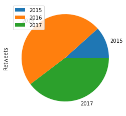

```python
new_general_tweet_dataset.groupby('Tweet_year')['Retweets'].sum().plot.pie(legend = True)
```

#### Let vizualize the number of favorite for each year

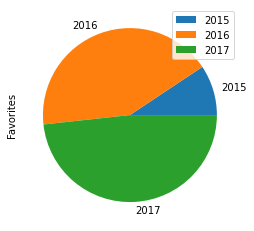

```python
new_general_tweet_dataset.groupby('Tweet_year')['Favorites'].sum().plot.pie(legend = True)
```

#### Let vizualize the reliable prediction

The most reliable prediction is the first prediction

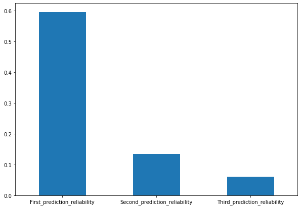

```python
new_general_tweet_dataset[['First_prediction_reliability','Second_prediction_reliability','Third_prediction_reliability']].mean().plot.bar(rot=0, figsize=[10,7])
```

#### Let vizualize the most tweet source used

The most used tweet source is Iphone

```python
#Check if the columns Tweet_source_x and Tweet_source_y are the same
len(new_general_tweet_dataset) == len(new_general_tweet_dataset[new_general_tweet_dataset.Tweet_source_x==new_general_tweet_dataset.Tweet_source_y])
```

```
True
```

```python
new_general_tweet_dataset['Tweet_source'] = new_general_tweet_dataset.Tweet_source_x
drop_column(new_general_tweet_dataset,'Tweet_source_x')
drop_column(new_general_tweet_dataset,'Tweet_source_y')
```

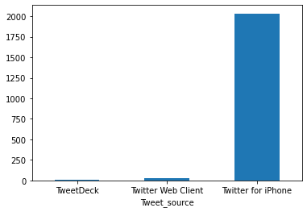

```python
new_general_tweet_dataset.groupby('Tweet_source')['Tweet_id'].count().plot.bar(rot=0)
```

```python
new_general_tweet_dataset.shape
```

```
(2073, 26)
```